# 第 14 章 因果关系与非平稳性

机器学习工具常受批评的一点，是它们大多按设计用于捕捉相关性，难以识别特征与标签之间的**因果关系**。相关性刻画的是双向联系 ($\textbf{X}\leftrightarrow \textbf{y}$)，而因果关系必须具有明确方向，即 $\textbf{X}\rightarrow \textbf{y}$ 或 $\textbf{X}\leftarrow \textbf{y}$，因此相关性所提供的信息要弱得多。市场情绪是一个常见例子。许多研究发现，无论如何定义，情绪似乎都能显著驱动未来收益率：投资者对某只股票情绪高涨，可能增加需求并推高股价。不过，反向推理也说得通：高情绪也可能预示均值回归即将发生。反向因果同样合理，即收益率影响情绪。一只股票若长期上涨，投资者会变得更加看多，情绪随之上升；这种行为尤其可能来自外推预期，参见 Barberis 等人（2015）的理论模型。Coqueret (2020) 得出了与该领域多数研究不同的结论：后一种关系，即收益率 $\rightarrow$ 情绪，更有可能成立。该结论得到因果检验的支持（见第 14.1.1 节）。

统计因果推断是一个庞大的研究领域，深入介绍可参阅 Pearl (2009)。近年来，研究者开始把因果推断与机器学习方法结合起来（例如 Peters、Janzing 和 Schölkopf (2017)、Heinze-Deml、Peters 和 Meinshausen (2018)、Arjovsky 等人 (2019)）。这些研究的一个核心概念是**不变性**。

数据通常不是一次性采集的，而是来自不同时间、不同来源。在这些环境中，有些关系会改变，有些则可能保持不变。能够在**环境变化**中保持稳定的关系，更可能源于因果机制，也更能提示因果关系。Beery、Van Horn 和 Perona (2018) 提供了一个反例：如果用常见图片训练计算机视觉算法区分牛和骆驼，算法可能学到的只是草地与沙地的区别，因为骆驼大多出现在沙漠，牛大多出现在绿色草地。于是，草地上的骆驼可能被识别为牛，沙地上的牛则可能被识别为骆驼。只有让两种动物出现在不同背景和环境中，模型才有机会识别真正区分牛与骆驼的属性。骆驼无论出现在哪里都仍是骆驼；若模型能始终正确识别它，就说明“骆驼”的表示在不同数据集中保持不变，模型也找到了真正起作用的属性，如整体轮廓、背部形状和面部特征等。颜色也可能有用，但同样可能误导。

在计算机视觉或自然语言处理等领域，寻找不变关系很有意义：猫的外观不会根本改变，语言结构也相对稳定。但金融市场是否存在类似的不变性并不明确。市场状态会随时间变化，公司特征与收益率之间的关系也可能逐年改变。一种应对方法，是正视这种**非平稳性**（平稳性的定义见第 1.1 节）。第 12 章建议使用滚动训练集尽可能频繁地更新模型，使预测更多反映最新趋势。第 14.2 节还将介绍其他理论与实践方案。

## 14.1 因果关系

传统机器学习模型旨在发现变量之间的关系，却通常不说明关系的*方向*。线性回归就是典型例子。若写成 $y=a+bx+\epsilon$，同样可以改写为 $x=b^{-1}(y-a-\epsilon)$，后者相对于 $y$ 仍是线性关系。这两个方程本身都不能说明 $x$ 是 $y$ 的原因，也就不能确立 $x \rightarrow y$ 而反向关系不成立。

### 14.1.1 格兰杰因果关系

Granger (1969) 提出的格兰杰因果检验大概是最著名、也最简单的工具。为便于说明，只考虑两个平稳过程 $X_t$ 和 $Y_t$。一种严格定义是：若称 $X$ 是 $Y$ 的格兰杰原因，则对某个整数 $k$ 有下式成立：

\begin{align} (Y_{t+1},\dots,Y_{t+k})|(\mathcal{F}_{Y,t}\cup \mathcal{F}_{X,t}) \quad \overset{d}{\neq} \quad (Y_{t+1},\dots,Y_{t+k})|\mathcal{F}_{Y,t}, \end{align}

也就是说，在同时掌握两个过程的信息时，$Y_t$ 未来取值的条件分布不同于仅掌握滤过 $\mathcal{F}_{Y,t}$ 时的条件分布。换言之，$X$ 的历史轨迹为预测 $Y$ 的未来轨迹提供了额外信息，并会改变对 $Y$ 未来轨迹的判断。

上述定义过于一般，难以直接数值计算，因此通常采用线性设定加以简化。沿用 Granger (1969) 原文第 5 节的记号，该检验包含两个回归：

\begin{align*} X_t&=\sum_{j=1}^ma_jX_{t-j}+\sum_{j=1}^mb_jY_{t-j} + \epsilon_t \\ Y_t&=\sum_{j=1}^mc_jX_{t-j}+\sum_{j=1}^md_jY_{t-j} + \nu_t \end{align*}

为简化分析，假设两个过程的均值都为零，并采用常规条件：高斯噪声 $\epsilon_t$ 与 $\nu_t$ 彼此不相关，在时间维度上也不相关。若至少一个 $b_j$ 非零，则称 $Y$ 是 $X$ 的格兰杰原因；若至少一个 $c_j$ 非零，则称 $X$ 是 $Y$ 的格兰杰原因。这两种情况可以同时成立，因此模型允许存在反馈回路。

统计检验的零假设为 $b_1=\dots=b_m=0$（反向检验则为 $c_1=\dots=c_m=0$），可使用常规的 F 分布进行检验。也可以放宽线性限制，但相应检验会复杂得多。金融领域的重要参考文献是 Hiemstra 和 Jones (1994)。

下面检验过去 6 个月的平均市值，是否是某只具体股票（样本中的第一只股票）未来 1 个月收益率的格兰杰原因。

```python
from statsmodels.tsa.stattools import grangercausalitytests

granger = training_sample.loc[training_sample["stock_id"]==1, # X variable = stock nb 1
                              ["R1M_Usd",                     # Y variable = stock nb 1
                               "Mkt_Cap_6M_Usd"]]             # & Market cap
fit_granger = grangercausalitytests(granger,maxlag=[6],verbose=True) # Maximmum lag
```

```
Granger Causality
number of lags (no zero) 6
ssr based F test:         F=4.1110  , p=0.0008  , df_denom=149, df_num=6
ssr based chi2 test:   chi2=26.8179 , p=0.0002  , df=6
likelihood ratio test: chi2=24.8162 , p=0.0004  , df=6
parameter F test:         F=4.1110  , p=0.0008  , df_denom=149, df_num=6
```

该检验具有方向性，只检验 $X$ 是否是 $Y$ 的格兰杰原因；若要检验反向关系，需要交换函数参数。上面的输出给出很低的 $p$ 值，说明在 $H_0$ 成立时观察到当前这类样本的概率极低。因此，市值似乎确实包含预测未来 1 个月收益率的信息。不过，格兰杰因果关系弱于下一小节讨论的因果关系：一个过程是另一个过程的格兰杰原因，只能说明前者含有有用的预测信息，并不能严格证明因果关系。此外，本检验只考虑线性模型，引入非线性或加入其他回归变量，包括可能遗漏的变量，都可能改变结论（参见 Chow、Cotsomitis 和 Kwan (2002)）。

### 14.1.2 因果加性模型

因果模型种类繁多，甚至第 9.5 节的 BART 也可用于因果推断，见 Hahn、Murray 和 Carvalho（2019）。进一步阅读可参考 Pearl (2009)、Peters、Janzing 和 Schölkopf (2017)、Maathuis 等人 (2018)、Hünermund 和 Bareinboim (2019) 及其引用的文献。因果模型的核心工具之一是 Pearl 提出的 **do-演算（干预演算）**。传统条件概率 $P[Y|X]$ 描述的是 $Y$ 在**观察到 $X$**取值 $x$ 时的概率，而 do($⋅$) 表示通过干预**令 $X$**取值 $x$。这一区别就是*观察*与*干预*之分。一个经典例子是气压计：观察气压计有助于判断天气，因为高气压通常与晴天相伴：

$P[\text{sunny weather}|\text{barometer says ``high''} ]>P[\text{sunny weather}|\text{barometer says ``low''} ],$

但如果人为操纵气压计，强制它显示某个读数，

$P[\text{sunny weather}|\text{barometer hacked to ``high''} ]=P[\text{sunny weather}|\text{barometer hacked ``low''} ],$

这是因为操纵气压计本身不会改变天气。简写为：对气压计实施干预时，$P[\text{weather}|\text{do(barometer)}]=P[\text{weather}]$。真正的上游变量是气压：它同时影响天气和气压计读数，因此是二者之间的混杂变量，由这一共同原因造成的关联称为混杂；气压计读数本身并不导致天气变化。希望深入理解这些概念的读者可参阅 Judea Pearl 的著作。do-演算是非常强大的理论框架，但并不容易直接应用于任意问题或数据集（例如参见 Aronow 和 Sävje (2019) 的书评）。

本章不打算完整梳理因果推断理论，而是展示几个容易解释的实际实现。因果模型很多，这里选择一种能用简单数学工具说明的方法。我们从结构因果模型（SCM）的最基本定义开始，记号沿用 Peters、Janzing 和 Schölkopf (2017) 第 3 章。这类模型的核心，是在变量之间加入层级关系，也就是额外的结构。形式化地，

\begin{align*} X&=\epsilon_X \\ Y&=f(X,\epsilon_Y), \end{align*}

其中 $\epsilon_X$ 和 $\epsilon_Y$ 是相互独立的噪声变量。直观地说，先随机生成一个 $X$ 的观测值，它随后影响 $Y$ 的观测值，而这一影响由 $f$ 传导。若观测变量更多，结构也会更复杂。例如再加入第三个变量：

\begin{align*} X&=\epsilon_X \\ Y&=f(X,\epsilon_Y),\\ Z&=g(Y,\epsilon_Z) \end{align*}

在这种情况下，$X$ 对 $Y$ 有因果效应，然后 $Y$ 对 $Z$ 有因果效应。因此我们有以下联系：

\begin{array}{ccccccc} X & &&&\\ &\searrow & &&\\ &&Y&\rightarrow&Z. \\ &\nearrow &&\nearrow& \\ \epsilon_Y & &\epsilon_Z \end{array}

上述表示称为图。下面简要介绍图论术语：变量称为*顶点*或*节点*，箭头称为*边*；带方向的箭头称为有向边。两个顶点若由一条边连接，就称为相邻。由一系列相邻顶点构成的序列称为*路径*；若路径上的边都有方向，则称为有向路径。在有向路径的一条边上，前一个顶点是父节点，后一个顶点是子节点。

图可以用邻接矩阵概括。邻接矩阵 $\textbf{A}=A_{ij}$ 只包含 0 和 1；若 $A_{ij}=1$，就表示存在从顶点 $i$ 指向顶点 $j$ 的边。通常不允许节点指向自身。以简化结构 $X \rightarrow Y \rightarrow Z$ 为例，各节点均不指向自身，因此矩阵对角线为零。该结构 $X \rightarrow Y \rightarrow Z$ 对应的邻接矩阵为

\begin{align} \textbf{A}=\begin{bmatrix} 0 & 1 & 0 \\ 0 & 0 & 1 \\ 0& 0&0 \end{bmatrix}. \end{align}

其中字母 $X$、$Y$ 和 $Z$ 自然按字母顺序排序。只有两个箭头：从 $X$ 到 $Y$（第一行第二列）和从 $Y$ 到 $Z$（第二行第三列）。

借助这些工具，可以写出一种非常一般的模型形式：

\begin{equation} \tag{14.1} X_j=f_j\left(\textbf{X}_{\text{pa}_D(j)},\epsilon_j \right), \end{equation}

其中噪声变量是相互独立的。符号 $\text{pa}_D(j)$ 指的是顶点 $j$ 在图结构 $D$ 中的父节点集。因此，$X_j$ 是其所有父节点和噪声项 $\epsilon_j$ 的函数。因果加性模型是上述设定的轻微简化：

\begin{equation} \tag{14.2} X_j=\sum_{k\in \text{pa}_D(j)}f_{j,k}\left(\textbf{X}_{k} \right)+\epsilon_j, \end{equation}

各变量的非线性效应以求和方式累积，因此称为*加性*模型。这里没有时间下标，因此不同于格兰杰因果关系，变量之间不存在天然的时间顺序。这类模型很复杂，也难以估计；详细方法见 Bühlmann 等人（2014）。作者同时开发了一个用于确定 DAG $D$ 的 R 软件包。

下面在训练样本上，使用一组精简预测变量和未来 1 个月收益率构建邻接矩阵，并测试 ICPy 软件包。

```python
import icpy as icpy

B=training_sample[['Mkt_Cap_12M_Usd','Vol1Y_Usd']].values          # Node B1 and B2
C=training_sample['R1M_Usd'].values                                # Node C
ExpInd=np.round(np.random.uniform(size=training_sample.shape[0]))  # "Environment"
icpy.invariant_causal_prediction(X=B,y=C,z=ExpInd,alpha=0.1)       # test if A or B are parents of C
```

```
ICP(S_hat=array([0, 1], dtype=int64), q_values=array([1.34146064e-215, 1.34146064e-215]), p_value=1.341460638715696e-215)
```

为完整起见，我们还给出 pcalg 软件包的 Python 版本实现（Kalisch 等人（2012））。29 下面采用所谓的 PC 算法进行估计；PC 取自两位作者 **P**eter Spirtes 和 **C**lark Glymour 的姓名首字母。算法细节超出本书范围，感兴趣的读者可参阅 Spirtes 等人 (2000) 第 5.4 节或 Kalisch 等人（2012）第 2 节。

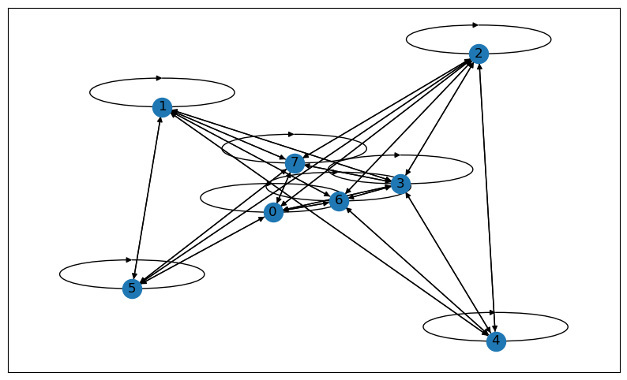

```python
import cdt
import networkx as nx
import matplotlib.pyplot as plt

data_caus = training_sample[features_short+["R1M_Usd"]]
dm = np.array(data_caus)
cm = np.corrcoef(dm.T)                          # Compute correlations
df=pd.DataFrame(cm)

glasso = cdt.independence.graph.Glasso()        # intialize graph lasso
skeleton = glasso.predict(df)                   # apply graph lasso to dataset
model_pc = cdt.causality.graph.PC()             # PC algo. from pcalg R library
graph_pc = model_pc.predict(df, skeleton)       # Estimate model
fig=plt.figure(figsize=[10,6])
nx.draw_networkx(model_pc)                      # Plot model
```

图 14.1：有向图的表示。

### 14.1.3 结构时间序列模型

因果关系部分最后介绍一类特殊的结构模型：**结构时间序列模型**。下面用它说明一种具体的因果推断方法，并沿用 Brodersen 等人（2015）的记号。模型由两个方程组成：

\begin{align*} y_t&=\textbf{Z}_t'\boldsymbol{\alpha}_t+\epsilon_t \\ \boldsymbol{\alpha}_{t+1}& =\textbf{T}_t\boldsymbol{\alpha}_{t}+\textbf{R}_t\boldsymbol{\eta}_t. \end{align*}

第一个方程把因变量表示为状态变量 $\boldsymbol{\alpha}_t$ 的线性函数加误差项。第二个方程又把状态变量写成其滞后值的线性函数，并加入另一个可具有复杂结构的误差项，即矩阵 $\textbf{R}_t$ 与零均值高斯项 $\boldsymbol{\eta}_t$ 的乘积。该设定可以把许多模型作为特例包含在内，例如 ARIMA。

Brodersen 等人（2015）通过状态或机制变化来识别因果影响。他们先在给定训练期估计上述模型，再预测测试期中的响应。若实际值与预测值之间的累计误差（求和或积分）经统计检验后显著，便认为该断点具有实质影响。这一方法最初用于量化干预效果：考察干预前训练的模型，在干预发生后会产生怎样的预测偏差。

下面检验样本中的第 100$^{th}$ 个日期点（2008 年 4 月）是否构成转折点。该日期处于次贷危机期间。这里使用 *CausalImpact* 模块的 Python 版本。

与模型相关的时间序列如图 14.2 所示。

```
                                Average       Cumulative
Actual                                0               86
Predicted                             0               76
95% CI                           [0, 1]        [45, 107]

Absolute Effect                       0               10
95% CI                           [0, 0]        [40, -20]

Relative Effect                   13.4%            13.4%
95% CI                  [53.5%, -26.7%]  [53.5%, -26.7%]

P-value                            0.0%
Prob. of Causal Effect           100.0%
None
```

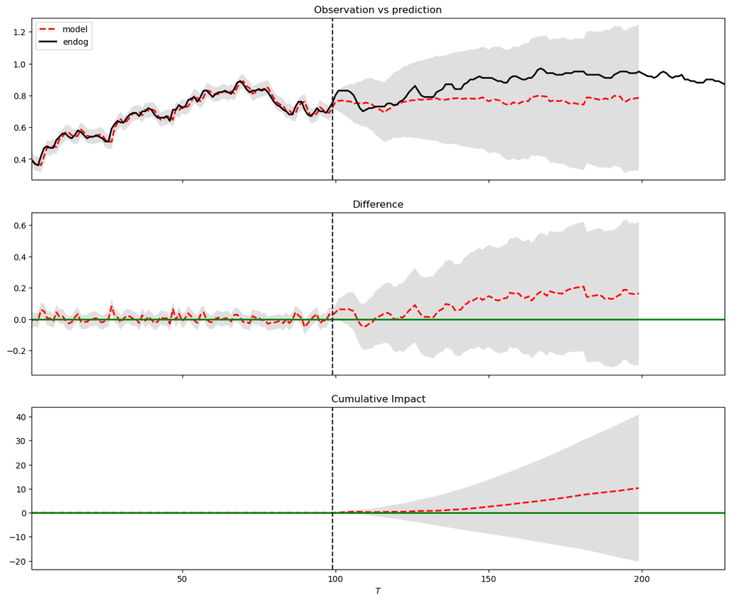

```python
from causalimpact import CausalImpact

stock1_data = data_ml.loc[data_ml["stock_id"]==1, :]                # Data of first stock
struct_data = stock1_data[["Advt_3M_Usd"]+features_short]           # Combine label and features
struct_data.index = pd.RangeIndex(start=0, stop=228, step=1)        # Setting index as int
pre_period = [0, 99]                                                # Pre-break period (pre-2008)
post_period = [100, 199]                                            # Post-break period

impact = CausalImpact(struct_data, pre_period, post_period)         # Causal model created
impact.run()                                                        # run!
print(impact.summary())                                             # Summary analysis
impact.plot()                                                       # Plot!
```

图 14.2：因果影响研究的输出。

## 14.2 应对不断变化的环境

机器学习研究最常见的假设，是所研究的样本来自某一待刻画现象的独立同分布（i.i.d.）观测。这一假设很自然：如果 $X$ 与 $y$ 的关系始终变化，就很难从已有观测中推断稳定规律。金融领域的主要困难之一，恰恰是市场、行为和政策都在持续演变。这至少部分源于无套利逻辑：若某种交易策略始终有效，投资者最终会因羊群效应纷纷采用它，从而消除相应收益。30 若策略始终保密，其持有者则会无限积累财富，但现实中从未出现这种情况。

环境变化可以有多种定义。以 $\mathbb{P}_{XY}$ 表示所有变量（特征与标签）的联合分布，并写成 $\mathbb{P}_{XY}=\mathbb{P}_{X}\mathbb{P}_{Y|X}$，则至少有两种基本变化：

- **协变量偏移**：$\mathbb{P}_{X}$ 发生变化，但 $\mathbb{P}_{Y|X}$ 不变。也就是说，特征分布发生波动，但特征与 $Y$ 的关系保持不变；
- **概念漂移**：$\mathbb{P}_{Y|X}$ 发生变化，但 $\mathbb{P}_{X}$ 不变。也就是说，特征分布保持稳定，但特征与 $Y$ 的关系发生改变。

这里暂不讨论两者同时变化的情况，因为那会复杂得多。在因子投资中，特征工程流程（见第 4.4 节）的部分目的，就是降低协变量偏移的风险。均匀化可以保证各特征的边际分布不变，但特征之间的相关结构仍可能变化。更棘手的问题通常是概念漂移，即特征解释标签的方式随时间改变。Cornuejols、Miclet 和 Barra（2018）31 区分了四类漂移，图 14.3 对此作了概括。在因子模型中，变化往往是四类漂移的组合：市场崩盘期间可能突然发生，更多时候则是渐进的，包括逐步变化或增量变化，而且可能持续反复出现。

[figure not shown]

图 14.3：概念变化的不同类型。

既然环境会变化，模型也应随之动态调整。但这会产生所谓的**稳定性-可塑性困境**：一方面希望模型具有较强的**反应性**，让新样本对更新产生足够影响；另一方面又希望保持**稳定性**，因为新样本未必代表较慢的长期趋势，过度响应可能把模型推向次优方向。

实践中有两种方式调节这一权衡：改变训练样本覆盖的时间长度，例如纳入更早的数据；或在条件允许时，为较新的样本赋予更高权重。第一种方法已在第 12.1 节讨论，第二种在第 6.3 节有所提及，不过 Adaboost 的目标正是让算法自行处理样本权重。一般而言，神经网络可以在损失函数中加入样本权重，尽管据我们所知，Keras 当时尚未提供这一选项，而该框架更新很快。对简单回归而言，这一思想称为**加权最小二乘法**，即在损失函数中为误差赋权：

\begin{align} L=\sum_{i=1}^Iw_i(y_i-\textbf{x}_i\textbf{b})^2. \end{align}

写成矩阵形式，$L=(\textbf{y}-\textbf{Xb})'\textbf{W}(\textbf{y}-\textbf{Xb})$，其中 $textbf{W}$ 是由样本权重构成的对角矩阵。损失关于 $\textbf{b}$ 的梯度为 $2\textbf{X}'\textbf{WX}\textbf{b}-2\textbf{X}'\textbf{Wy}$，因此最小化损失的解为 $\textbf{b}^*=(\textbf{X}'\textbf{WX})^{-1}\textbf{X}'\textbf{Wy}$。令 $\textbf{W}=\textbf{I}$，即可得到普通最小二乘解。若要提高模型对新信息的反应速度，可以让权重随样本在训练集中的“年龄”增加而递减。

不断变化的金融环境没有完美解法。下文将介绍机器学习文献中应对数据生成过程非平稳性的两条路径。在此之前，先用另一个直观例子说明市场分布确实会随时间变化。

### 14.2.1 非平稳性：另一个示例

金融计量经济学最基本的做法之一，是研究收益率，也就是价格的相对变化。原因很简单：收益率在不同时期具有相对一致的尺度，例如月收益率有界，通常位于 -1 与 +1 之间。价格水平则会持续移动，有些价格甚至再也不会回到过去的区间，因此更难直接建模。

平稳性是金融计量经济学中的关键概念。若一个现象的分布性质不随时间变化，就更容易刻画和估计。但收益率分布并不真正平稳，其均值和方差都会随市场周期改变。

下面在图 14.4 中，我们通过计算整个数据集中所有日历年的平均月收益率来说明这一事实。

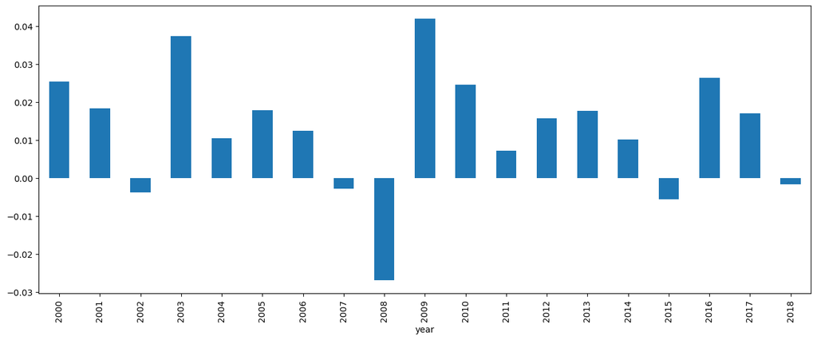

```python
data_ml["year"] = pd.to_datetime(data_ml['date']).dt.year           # Adding a year column for later groupby
data_ml.groupby("year")["R1M_Usd"].mean().plot.bar(figsize=[16,6])  # Agregatting and plotting
```

图 14.4：每年的平均月收益率。

均值变化通常还伴随着二阶矩，也就是方差或波动率的变化。这种现象称为波动率聚集，自 Engle (1982) 的理论突破以来，甚至更早，就有大量文献记录。更多细节可参阅 Cont (2007)；若要在 R 中计算已实现波动率，推荐阅读 Regenstein (2018) 第 4 章。

机器学习模型也会受到这种变化影响。下面只使用一个预测变量，即过去 6 个月的平均市值，估计特征回归 ($r_{t+1,n}=\alpha+\beta x_{t,n}^{\text{cap}}+\epsilon_{t+1,n}$)。标签为未来 6 个月收益率，并按每个日历年分别估计模型。

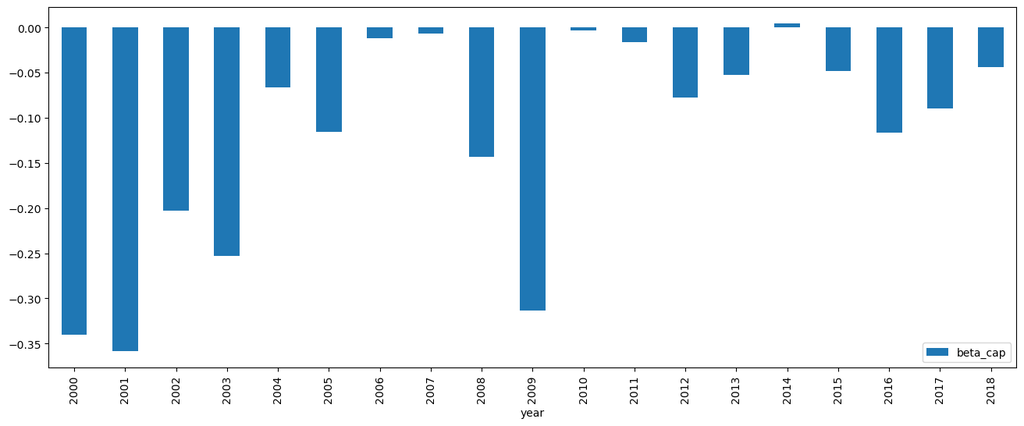

```python
import statsmodels.api as sm

def regress(df):                                                                    # To avoid loop and keep...
    model = sm.OLS(df['R6M_Usd'], exog=sm.add_constant(df[['Mkt_Cap_6M_Usd']]))     # ... the groupby structure we use...
    return model.fit().params[1]                                                    # ... a function with statsmodel

beta_cap = data_ml.groupby('year').apply(regress)                                   # Perform regression
beta_cap=pd.DataFrame(beta_cap,columns=['beta_cap']).reset_index()                  # Format into df
beta_cap.groupby("year").mean().plot.bar(figsize=[16,6])                            # Plot
```

图 14.5：贝塔值相对于 6 个月市值的变化。

图 14.5 的柱形清楚展示了概念漂移：总体而言，市值与收益率呈负相关，再次体现**规模效应**；但这种负向关系有时很强，有时很弱。市值解释收益率的能力随时间变化，模型也必须随之调整。

### 14.2.2 在线学习

在线学习是机器学习的一个分支：新信息持续到达，模型以迭代方式逐步吸收这些信息。这里的“在线”与互联网无关。要让最新数据影响预测，就必须持续更新模型；金融应用正是如此。这一主题与第 12.1 节关于训练窗口的讨论密切相关。

问题在于，若 2019 年的模型使用 2010 至 2019 年全部数据训练，那么更新到 2020 年时，通常要把 2020 年新数据加入整个数据集并重新训练，计算成本很高。若学习过程只吸收最新数据点，成本便可大幅降低。神经网络可以通过按批次连续更新权重，让模型逐步变化；决策树通常做不到这一点，因为分裂一旦确定便不会改变。Basak (2004) 是一个值得注意的例外，但其中树的构造方式与原始算法差别很大。

在线学习最简单的例子之一是 Widrow-Hoff 算法，源自 Widrow 和 Hoff (1960)。其思想来自 ADALINE（ADAptive LInear NEuron，自适应线性神经元）模型：一种只有单个隐藏层、采用线性激活函数的神经网络。它类似感知机，但激活方式不同。

假设模型是线性的，即 $\textbf{y}=\textbf{Xb}+\textbf{e}$（常数项可作为一个预测变量加入），同时数据规模很大、到达频率很高，因而无法每次都用全样本重新估计模型。系数向量 $\textbf{b}$ 可以采用下面这种简单的启发式方法更新：

\begin{align} \textbf{b}_{t+1} \longleftarrow \textbf{b}_t-\eta (\textbf{x}_t\textbf{b}-y_t)\textbf{x}_t', \end{align}

其中 $\textbf{x}_t$ 是第 $t$ 个样本的行向量。理由很直接：二次误差 $(\textbf{x}_t\textbf{b}-y_t)^2$ 关于 $\textbf{b}$ 的梯度为 $2(\textbf{x}_t\textbf{b}-y_t)\textbf{x}_t'$，所以上式就是一次简单的梯度下降更新。$\nu$ 必须取得足够小，否则每个新数据点都会大幅改变 $\textbf{b}$，使模型变得不稳定。

Hoi 等人 (2018) 对在线学习技术作了全面综述，其中第 4.11 节专门讨论投资组合选择。Hazan 等人（2016）的著作介绍在线凸优化，这一领域与在线学习高度重合。下面的内容主要改编自前一篇综述的第二、三部分。

数据集按时间索引，特征与标签分别记为 $\textbf{X}_t$ 和 $\textbf{y}_t$；本节不再使用通常的列索引 $(k)$ 与行索引 ($i$)。时间范围有上界 $T$。机器学习模型依赖参数 $\theta$，记为 $f_{\boldsymbol{\theta}}$。在时间 $t$ 收集数据集 ($\textbf{X}_t$,$\textbf{y}_t$) 后，已训练模型的损失函数 $L$ 自然同时依赖数据 ($\textbf{X}_t$,$\textbf{y}_t$) 与模型参数 $\theta_t$；后者是在时间 $t$ 的数据上拟合得到的参数值。为简化记号，下文写作 $L_t(\boldsymbol{\theta}_t)=L(\textbf{X}_t,\textbf{y}_t,\boldsymbol{\theta}_t )$。在线学习的核心指标是整个时间序列上的遗憾值：

\begin{equation} \tag{14.3} R_T=\sum_{t=1}^TL_t(\boldsymbol{\theta}_t)-\underset{\boldsymbol{\theta}^*\in \boldsymbol{\Theta}}{\inf} \ \sum_{t=1}^TL_t(\boldsymbol{\theta}^*). \end{equation}

遗憾值等于各期模型 $\boldsymbol{\theta}_t$ 产生的总损失，减去预先知道完整数据序列时所能取得的最小损失；后者只能事后计算。在线学习的基本方法其实与神经网络的批量训练很相似，参数按下式更新：

\begin{equation} \tag{14.4} \textbf{z}_{t+1}=\boldsymbol{\theta}_t-\eta_t\nabla L_t(\boldsymbol{\theta}_t), \end{equation}

其中 $\nabla L_t(\boldsymbol{\theta}_t)$ 表示当前损失 $L_t$ 的梯度。问题在于，$\textbf{z}_{t+1}$ 可能超出参数 $\boldsymbol{\theta}_t$ 的允许范围。因此，需要把新参数的候选向量 $\textbf{z}_{t+1}$ 投影到可行域 $S$ 上：

\begin{equation} \tag{14.5} \boldsymbol{\theta}_{t+1}=\Pi_S(\textbf{z}_{t+1}), \quad \text{with} \quad \Pi_S(\textbf{u}) = \underset{\boldsymbol{\theta}\in S}{\text{argmin}} \ ||\boldsymbol{\theta}-\textbf{u}||_2. \end{equation}

这样得到的 $\boldsymbol{\theta}_{t+1}$ 是可行域内最接近中间候选值 $\textbf{z}_{t+1}$ 的参数。Hazan、Agarwal 和 Kale (2007) 证明，在适当假设下，例如 $L_t$ 严格凸且梯度有界 $\left|\left|\underset{\boldsymbol{\theta}}{\sup} \, \nabla L_t(\boldsymbol{\theta})\right|\right|\le G$，遗憾值 $R_T$ 满足

\begin{align} R_T \le \frac{G^2}{2H}(1+\log(T)), \end{align}

其中 $H$ 是学习率的缩放因子（也称为步长）：$\eta_t=(Ht)^{-1}$。

更复杂的在线算法会在式 (14.4) 和 (14.5) 的基础上引入 Hessian 矩阵 $\nabla^2 L_t(\boldsymbol{\theta}):=[\nabla^2 L_t]_{i,j}=\frac{\partial}{\partial \boldsymbol{\theta}_i \partial \boldsymbol{\theta}_j}L_t( \boldsymbol{\theta})$，或加入惩罚项以降低 $\boldsymbol{\theta}_t$ 的不稳定性。关于这些扩展，详见 Hoi 等人 (2018) 第 2 节。

另一类有趣的参数更新方法，是 Crammer 等人 (2006) 形式化的被动-激进算法（PAA）。原始设定主要针对分类任务，下面沿用其第 5 节的回归版本。PAA 的一个重要限制，是它依赖于损失为零或可忽略的一组参数：$\boldsymbol{\Theta}^*_\epsilon=\{\boldsymbol{\theta}, L_t(\boldsymbol{\theta})< \epsilon\}$。对一般损失函数和学习器 $f$，这一集合通常难以求得。因此，Crammer 等人 (2006) 把算法限制在线性 $f$ 与 $\epsilon$ 不敏感铰链损失这一特定情形：

\begin{align} L_\epsilon(\boldsymbol{\theta})=\left\{ \begin{array}{ll} 0 & \text{if } \ |\boldsymbol{\theta}'\textbf{x}-y|\le \epsilon \quad (\text{close enough prediction}) \\ |\boldsymbol{\theta}'\textbf{x}-y|- \epsilon & \text{if } \ |\boldsymbol{\theta}'\textbf{x}-y| > \epsilon \quad (\text{prediction too far}) \end{array}\right., \end{align}

其中参数 $\epsilon>0$。若参数 $\theta$ 使预测与实际值足够接近，则损失为零；否则，损失等于绝对误差减去 $\epsilon$。PAA 的参数更新为

\begin{align} \boldsymbol{\theta}_{t+1}= \underset{\boldsymbol{\theta}}{\text{argmin}} ||\boldsymbol{\theta}-\boldsymbol{\theta}_t||_2^2, \quad \text{subject to} \quad L_\epsilon(\boldsymbol{\theta})=0, \end{align}

因此，选择新的参数值以满足两个条件：

- 损失为零，即按定义，模型预测与实际值足够接近；
- 新参数尽可能接近上一期参数。

按这一构造，若当前模型已经足够好，参数保持不变，处于“被动”阶段；若模型表现不足，参数就会迅速调整到能产生满意结果的位置，进入“激进”阶段。

本节最后补充一点历史背景。在线学习的一些思想来自金融文献，尤其是 Cover (1991) 提出的**通用投资组合**。设函数 $f$ 为线性形式，并令权重满足预算约束 $\boldsymbol{\theta}'\textbf{1}_N=1$。数据 $\mathbf{x}_t$ 是资产收益率；只要满足 $\boldsymbol{\theta}'\textbf{1}_N=1$，模型输出就是投资组合收益率。损失函数 $L_t$ 对应一个凹效用函数，例如对数效用，因此遗憾值的方向相反：

\begin{align} R_T=\underset{\boldsymbol{\theta}^*\in \boldsymbol{\Theta}}{\sup} \ \sum_{t=1}^TL_t(\textbf{r}_t'\boldsymbol{\theta}^*)-\sum_{t=1}^TL_t(\textbf{r}_t'\boldsymbol{\theta}_t), \end{align}

其中 $\textbf{r}_t'$ 表示收益率。这样，优化问题就转化为最大化凹函数。计算机科学与机器学习领域的多篇研究提出了相应算法，包括 Blum 和 Kalai (1999)、Agarwal 等人 (2006) 以及 Hazan、Agarwal 和 Kale (2007)。多数研究只使用价格数据，Cover 和 Ordentlich (1996) 是一个重要例外，它还考虑了外部数据，即“*辅助信息*”。该文证明，按两类随机分布持续再平衡的投资组合，其增长率可以接近不可实现的最优增长率。这两类分布分别是均匀分布，也就是再次使用等权配置，以及参数恒为 1/2 的狄利克雷分布。在这一通用分布下，Cover 和 Ordentlich（1996）证明所得财富满足下界：

\begin{align} \text{wealth universal} \ge \frac{\text{wealth from optimal strategy}}{2(n+1)^{(m-1)/2}}, \end{align}

其中 $m$ 是资产数量，$n$ 是期间数量。

Li 和 Hoi (2014) 综述了在线投资组合配置文献，Li 和 Hoi (2018) 则给出了更详细的介绍。Wong 等人（2020）把在线学习与神经网络的早停结合，用于因子投资；Khedmati 和 Azin（2020）还把在线学习与聚类方法结合，用于投资组合选择。

### 14.2.3 同质迁移学习

本小节以概念介绍为主，不提供代码示例。迁移学习的思想有助于启发新的建模方案，因此值得在此作简要说明。

迁移学习已有多篇综述。Pan 和 Yang (2009) 是经典参考文献，Weiss、Khoshgoftaar 和 Wang (2016) 则更新、更全面。假设有两个数据集：源数据 $D_S$ 与目标数据 $D_T$。二者分别具有特征 $\mathbf{X}^S$、$\mathbf{X}^T$ 和标签 $\mathbf{y}^S$、$\mathbf{y}^T$。传统监督学习只通过 $\mathbf{X}^T$ 与 $\mathbf{y}^T$ 学习目标数据中的规律。迁移学习则利用源数据来改进目标函数 $f^T$，后者通过拟合目标数据上的 $y_i^T=f^T(\textbf{x}_i^T)+\epsilon^T_i$ 得到；源数据提供的函数为 $f^S$，来自 $y_i^S=f^S(\textbf{x}_i^S)+\varepsilon^S_i$。若源域与目标域的特征空间不变，就称为同质迁移学习，本书设定大体属于这种情形。但资产管理中若加入新的预测变量，例如来自情绪、卫星图像或信用卡记录等另类数据，特征空间也可能发生变化。

迁移学习的子类型取决于源域 $S$ 与目标域 $T$ 之间究竟发生了什么变化：特征空间、标签分布，还是二者之间的关系？这些问题与第 14.2 节讨论的环境变化相同。金融中尤其值得关注第三种情况，因为它直接对应非平稳性，也就是模型 $f$ 在 $\textbf{y}=f(\textbf{X})$ 中随时间变化。用迁移学习的记号表示，就是 $P[\textbf{y}^S|\textbf{X}^S]\neq P[\textbf{y}^T|\textbf{X}^T]$：从源域转到目标域后，给定特征的标签条件分布发生改变。“域适应”（domain adaptation）常被用作迁移学习的近义词，因为数据发生偏移后，需要相应调整模型以提高准确度。Quionero-Candela 等人（2009）编著的文集用多个章节综述了这些主题。

Ben-David 等人（2010）针对二元分类证明了一个重要且简洁的结果。设 $f$ 与 $h$ 是两个取值属于 $\{0,1 \}$ 的分类器，它们在域 $S$ 上的平均差异定义为

\begin{align} \epsilon_S(f,h)=\mathbb{E}_S[|f(\textbf{x})-h(\textbf{x})|]. \end{align}

则有

\begin{equation} \small \epsilon_T(f_T,h)\le \epsilon_S(f_S,h)+\underbrace{2 \sup_B|P_S(B)-P_T(B)|}_{\text{ difference between domains }} + \underbrace{ \min\left(\mathbb{E}_S[|f_S(\textbf{x})-f_T(\textbf{x})|],\mathbb{E}_T[|f_S(\textbf{x})-f_T(\textbf{x})|]\right)}_{\text{difference between the two learning tasks}}, \nonumber \end{equation}

其中 $P_S$ 和 $P_T$ 表示两个域的分布。上述不等式给出了 $h$ 泛化误差的上界。若 $f_S$ 是域 $S$ 上的最优分类器，$f_T$ 是域 $T$ 上的最优分类器，则 $h$ 在 $T$ 上的误差不超过以下三项之和：

- $S$ 域中的误差；
- 两个域之间的距离，即数据空间发生了多大偏移；
- 两个最优模型（数据生成机制）之间的距离。

迁移学习中常用的一种方法是样本加权。下面在一般设定下介绍这一思路。机器学习的目标是最小化

\begin{align*} \epsilon_T(f)=\mathbb{E}_T\left[L(\text{y},f(\textbf{X})) \right], \end{align*}

其中 $L$ 是取决于具体任务的损失函数，例如回归与分类采用不同的损失。上式可改写为

\begin{align*} \epsilon_T(f)&=\mathbb{E}_T \left[\frac{P_S(\textbf{y},\textbf{X})}{P_S(\textbf{y},\textbf{X})} L(\text{y},f(\textbf{X})) \right] \\ &=\sum_{\textbf{y},\textbf{X}}P_T(\textbf{y},\textbf{X})\frac{P_S(\textbf{y},\textbf{X})}{P_S(\textbf{y},\textbf{X})} L(\text{y},f(\textbf{X})) \\ &=\mathbb{E}_S \left[\frac{P_T(\textbf{y},\textbf{X})}{P_S(\textbf{y},\textbf{X})} L(\text{y},f(\textbf{X})) \right] \end{align*}

因此，关键量是密度比 $\frac{P_T(\textbf{y},\textbf{X})}{P_S(\textbf{y},\textbf{X})}$，在一定假设下即 Radon-Nikodym 导数。实践中通常无法直接得到这一比率，但可以设计样本加权方案，以降低目标域中的误差。与 Coqueret 和 Guida (2020) 类似，权重也可以是二元的，即把部分观测从误差计算中排除。换言之，从训练样本中移除某些观测，有时反而会改善模型。

更一般地，上述表达式为用户指定样本权重提供了理论依据（见第 6.4.7 节）。用资产配置的语言说，这相当于加入分析者对“哪些观测更有价值”的观点。例如，若认为价值股包含更多相关信息，就可以在计算损失时赋予价值股更高权重；模型仍以最小化加权后的损失为目标。

最后介绍 Koshiyama 等人（2020）的一个迁移学习应用。作者提出一种神经网络架构，使不同策略能够跨多个市场共享学习过程；该方法的目标之一，是缓解回测过拟合。

### 参考文献

Agarwal, Amit, Elad Hazan, Satyen Kale, and Robert E Schapire. 2006. “Algorithms for Portfolio Management Based on the Newton Method.” In Proceedings of the 23rd International Conference on Machine Learning, 9–16. ACM.

Arjovsky, Martin, Léon Bottou, Ishaan Gulrajani, and David Lopez-Paz. 2019. “Invariant Risk Minimization.” arXiv Preprint, no. 1907.02893.

Aronow, Peter M., and Fredrik Sävje. 2019. “Book Review. The Book of Why: The New Science of Cause and Effect.” Journal of the American Statistical Association 115 (529): 482–85.

Barberis, Nicholas, Robin Greenwood, Lawrence Jin, and Andrei Shleifer. 2015. “X-CAPM: An Extrapolative Capital Asset Pricing Model.” Journal of Financial Economics 115 (1): 1–24.

Basak, Jayanta. 2004. “Online Adaptive Decision Trees.” Neural Computation 16 (9): 1959–81.

Beery, Sara, Grant Van Horn, and Pietro Perona. 2018. “Recognition in Terra Incognita.” In Proceedings of the European Conference on Computer Vision (Eccv), 456–73.

Ben-David, Shai, John Blitzer, Koby Crammer, Alex Kulesza, Fernando Pereira, and Jennifer Wortman Vaughan. 2010. “A Theory of Learning from Different Domains.” Machine Learning 79 (1-2): 151–75.

Blum, Avrim, and Adam Kalai. 1999. “Universal Portfolios with and Without Transaction Costs.” Machine Learning 35 (3): 193–205.

Brodersen, Kay H, Fabian Gallusser, Jim Koehler, Nicolas Remy, Steven L Scott, and others. 2015. “Inferring Causal Impact Using Bayesian Structural Time-Series Models.” Annals of Applied Statistics 9 (1): 247–74.

Bühlmann, Peter, Jonas Peters, Jan Ernest, and others. 2014. “CAM: Causal Additive Models, High-Dimensional Order Search and Penalized Regression.” Annals of Statistics 42 (6): 2526–56.

Chow, Ying-Foon, John A Cotsomitis, and Andy CC Kwan. 2002. “Multivariate Cointegration and Causality Tests of Wagner’s Hypothesis: Evidence from the UK.” Applied Economics 34 (13): 1671–7.

Cont, Rama. 2007. “Volatility Clustering in Financial Markets: Empirical Facts and Agent-Based Models.” In Long Memory in Economics, 289–309. Springer.

Coqueret, Guillaume. 2020. “Stock Specific Sentiment and Return Predictability.” Quantitative Finance Forthcoming.

Coqueret, Guillaume, and Tony Guida. 2020. “Training Trees on Tails with Applications to Portfolio Choice.” Annals of Operations Research 288: 181–221.

Cornuejols, Antoine, Laurent Miclet, and Vincent Barra. 2018. Apprentissage Artificiel: Deep Learning, Concepts et Algorithmes. Eyrolles.

Cover, Thomas M. 1991. “Universal Portfolios.” Mathematical Finance 1 (1): 1–29.

Cover, Thomas M, and Erik Ordentlich. 1996. “Universal Portfolios with Side Information.” IEEE Transactions on Information Theory 42 (2): 348–63.

Crammer, Koby, Ofer Dekel, Joseph Keshet, Shai Shalev-Shwartz, and Yoram Singer. 2006. “Online Passive-Aggressive Algorithms.” Journal of Machine Learning Research 7 (Mar): 551–85.

Engle, Robert F. 1982. “Autoregressive Conditional Heteroscedasticity with Estimates of the Variance of United Kingdom Inflation.” Econometrica, 987–1007.

Granger, Clive WJ. 1969. “Investigating Causal Relations by Econometric Models and Cross-Spectral Methods.” Econometrica, 424–38.

Hahn, P Richard, Jared S Murray, and Carlos Carvalho. 2019. “Bayesian Regression Tree Models for Causal Inference: Regularization, Confounding, and Heterogeneous Effects.” arXiv Preprint, no. 1706.09523.

Hazan, Elad, Amit Agarwal, and Satyen Kale. 2007. “Logarithmic Regret Algorithms for Online Convex Optimization.” Machine Learning 69 (2-3): 169–92.

Hazan, Elad, and others. 2016. “Introduction to Online Convex Optimization.” Foundations and Trends in Optimization 2 (3-4): 157–325.

Heinze-Deml, Christina, Jonas Peters, and Nicolai Meinshausen. 2018. “Invariant Causal Prediction for Nonlinear Models.” Journal of Causal Inference 6 (2).

Hiemstra, Craig, and Jonathan D Jones. 1994. “Testing for Linear and Nonlinear Granger Causality in the Stock Price-Volume Relation.” Journal of Finance 49 (5): 1639–64.

Hoi, Steven CH, Doyen Sahoo, Jing Lu, and Peilin Zhao. 2018. “Online Learning: A Comprehensive Survey.” arXiv Preprint, no. 1802.02871.

Hünermund, Paul, and Elias Bareinboim. 2019. “Causal Inference and Data-Fusion in Econometrics.” arXiv Preprint, no. 1912.09104.

Kalisch, Markus, Martin Mächler, Diego Colombo, Marloes H Maathuis, Peter Bühlmann, and others. 2012. “Causal Inference Using Graphical Models with the R Package Pcalg.” Journal of Statistical Software 47 (11): 1–26.

Khedmati, Majid, and Pejman Azin. 2020. “An Online Portfolio Selection Algorithm Using Clustering Approaches and Considering Transaction Costs.” Expert Systems with Applications Forthcoming: 113546.

Koshiyama, Adriano, Sebastian Flennerhag, Stefano B Blumberg, Nick Firoozye, and Philip Treleaven. 2020. “QuantNet: Transferring Learning Across Systematic Trading Strategies.” arXiv Preprint, no. 2004.03445.

Li, Bin, and Steven CH Hoi. 2014. “Online Portfolio Selection: A Survey.” ACM Computing Surveys (CSUR) 46 (3): 35.

Li, Bin, and Steven Chu Hong Hoi. 2018. Online Portfolio Selection: Principles and Algorithms. CRC Press.

Maathuis, Marloes, Mathias Drton, Steffen Lauritzen, and Martin Wainwright. 2018. Handbook of Graphical Models. CRC Press.

Pan, Sinno Jialin, and Qiang Yang. 2009. “A Survey on Transfer Learning.” IEEE Transactions on Knowledge and Data Engineering 22 (10): 1345–59.

Pearl, Judea. 2009. Causality: Models, Reasoning and Inference. Second Edition. Vol. 29. Cambridge University Press.

Peters, Jonas, Dominik Janzing, and Bernhard Schölkopf. 2017. Elements of Causal Inference: Foundations and Learning Algorithms. MIT Press.

Quionero-Candela, Joaquin, Masashi Sugiyama, Anton Schwaighofer, and Neil D Lawrence. 2009. Dataset Shift in Machine Learning. MIT Press.

Regenstein, Jonathan K. 2018. Reproducible Finance with R: Code Flows and Shiny Apps for Portfolio Analysis. Chapman & Hall / CRC.

Spirtes, Peter, Clark N Glymour, Richard Scheines, and David Heckerman. 2000. Causation, Prediction, and Search. MIT Press.

Tikka, Santtu, and Juha Karvanen. 2017. “Identifying Causal Effects with the R Package Causaleffect.” Journal of Statistical Software 76 (1): 1–30.

Weiss, Karl, Taghi M Khoshgoftaar, and DingDing Wang. 2016. “A Survey of Transfer Learning.” Journal of Big Data 3 (1): 9.

Widrow, Bernard, and Marcian E Hoff. 1960. “Adaptive Switching Circuits.” In IRE Wescon Convention Record, 4:96–104.

Wong, Steven YK, Jennifer Chan, Lamiae Azizi, and Richard YD Xu. 2020. “Time-Varying Neural Network for Stock Return Prediction.” arXiv Preprint, no. 2003.02515.

1. 例如，请参阅有关因子投资中羊群效应的论文：Krkoska 和 Schenk-Hoppé (2019) 以及 Santi 和 Zwinkels (2018)。↩︎
2. 这本书可能是机器学习理论成果最完整的参考书，但它是法语的。↩︎